# Tutorial - Decision Theory

This tutorial needs some calculation, but minimal programming. Use Excel, R, Python, a calculator or whatever else you want.

**Note:** If you’re interested in a package that can draw decision trees in R I recommend `data.tree`. You can see the R code used to create the trees in this tutorial (use the ‘Show’ buttons to see the code). These methods are not examinable, and also note that in the test you will need to be able to carry out the relevant calculations of expected utilities by hand.

#### Probability Review

In a data science class the distribution of grades $\\Pr(G=g)$ over the 11 possible grade typically as follows:

```r
gdist <- data.frame(gnames=c("E","D","C-","C","C+","B-","B","B+","A-","A","A+"),
                    gpval=c(0,0,1:9),
                    pg=c(11,5, 10,12,17, 23,28,29, 32,22,11)/2/100,
                    pa.g=c(20,30, 35,40,45, 60,65,80, 85,90,90)/100)
rownames(gdist) <- gdist$gnames
pa <- sum(gdist$pg*gdist$pa)

sgdist <- gdist
sgdist$pg <- sprintf("%.3f",sgdist$pg)
sgdist$pa.g <- sprintf("%.3f",sgdist$pa.g)
tgdist <- t(sgdist[,-1])
#colnames(tgdist) <- gdist$gnames
tgdist <- cbind(Grades=c(
                  "Grade points, $c(g)$",
                  "Grade distribution, $\\Pr(G=g)$",
                  "Attendance rate $\\Pr(A=1|G=g)$"),
                tgdist)
tgdist %>%
  kbl(row.names=FALSE, align="lccccccccccc") %>%
  kable_styling(full_width=FALSE)
```

| Grades | E | D | C- | C | C+ | B- | B | B+ | A- | A | A+ |
| --- | --- | --- | --- | --- | --- | --- | --- | --- | --- | --- | --- |
| Grade points, $c(g)$ | 0 | 0 | 1 | 2 | 3 | 4 | 5 | 6 | 7 | 8 | 9 |
| Grade distribution, $\Pr(G=g)$ | 0.055 | 0.025 | 0.050 | 0.060 | 0.085 | 0.115 | 0.140 | 0.145 | 0.160 | 0.110 | 0.055 |
| Attendance rate $\Pr(A=1\|G=g)$ | 0.200 | 0.300 | 0.350 | 0.400 | 0.450 | 0.600 | 0.650 | 0.800 | 0.850 | 0.900 | 0.900 |

```r
gdist$pg.a <- gdist$pa.g*gdist$pg/pa
gp <- sum(gdist$gpval*gdist$pg)
gpa <- sum(gdist$gpval*gdist$pg.a)
```

Also shown for each grade $g$ is the proportion of students who attend lectures regularly $A=1$.

These data are also in the file `GradeDistribution.csv`.

##### Questions

1. Draw a bar chart of the probability distribution of grades $\Pr(G=g)$
2. What is the mean grade point value achieved in the class?
3. What proportion of the class attends lectures regularly?
4. What proportion of the class that attends will receive a B+ grade?
5. What is the mean grade point value achieved among those attending lectures regularly?

##### Answers

1. Draw a bar chart of the probability distribution of grades

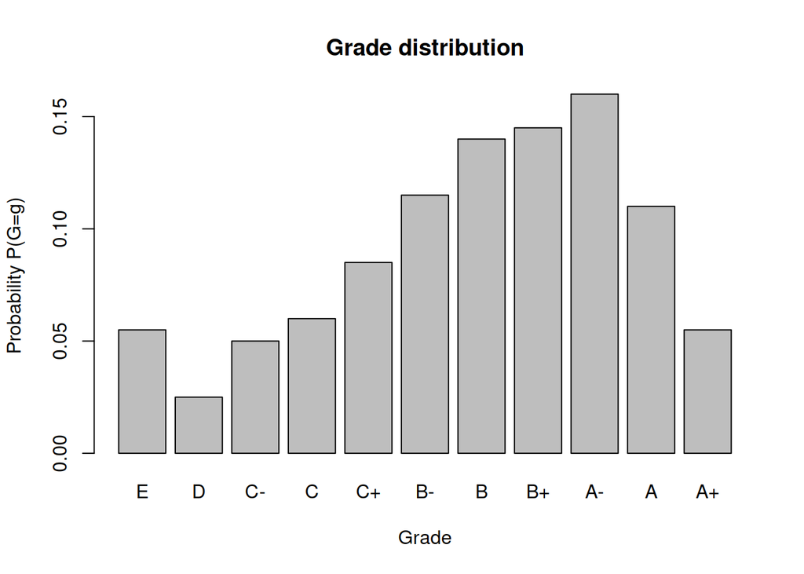

   ```r
   barplot(gdist$pg, names=gdist$gnames, xlab="Grade", ylab="Probability P(G=g)")
   title("Grade distribution")
   ```

2. What is the mean grade point value achieved in the class?

   This is
   $$\begin{eqnarray*}
   E[c(G)] &=& \sum_g c(g) \Pr(G=g)\\
   &=& c({\tt E})\Pr(G=\mbox{$\tt{E}$}) +
   c({\tt D})\Pr(G=\mbox{$\tt{D}$}) \\
   & & \qquad + \ldots +
   c({\tt A+})\Pr(G=\mbox{$\tt{A+}$})\\
   &=& (0)(0.055) +
   (0)(0.025) +
   \ldots
   + (9)(0.055)\\
   &=& 4.950
   \end{eqnarray*}$$
3. What proportion of the class attends lectures regularly?

   This is the probability $\Pr(A=1)$
   $$\begin{eqnarray*}
   \Pr(A=1) &=& E[\Pr(A=1|G)]\\
   &=& \sum_{g} \Pr(A=1,G=g)\\
   &=& \sum_{g} \Pr(A=1|G=g)\Pr(G=g)\\
   &=& \Pr(A=1|G=\mbox{$\tt{E}$})\Pr(G=\mbox{$\tt{E}$})
   +
   \Pr(A=1|G=\mbox{$\tt{D}$})\Pr(G=\mbox{$\tt{D}$})\\
   & & \qquad + \ldots +
   \Pr(A=1|G=\mbox{$\tt{A+}$})\Pr(G=\mbox{$\tt{A+}$})\\
   &=& (0.200)(0.055) +
   (0.300)(0.025) +
   \ldots
   + (0.900)(0.055)\\
   &=& 0.659
   \end{eqnarray*}$$
4. What proportion of the class that attends will receive a B+ grade?

   This is the probability $\Pr(G={\tt B+}|A=1)$ - we can use Bayes’ Rule to calculate it:
   $$\begin{eqnarray*}
   \Pr(G={\tt B+}|A=1)
   &=& \frac{\Pr(A=1|G={\tt B+})\Pr(G={\tt B+})}{\Pr(A=1)}\\
   &=& \frac{(0.800)(0.145)}{0.659}\\
   &=& 0.176
   \end{eqnarray*}$$

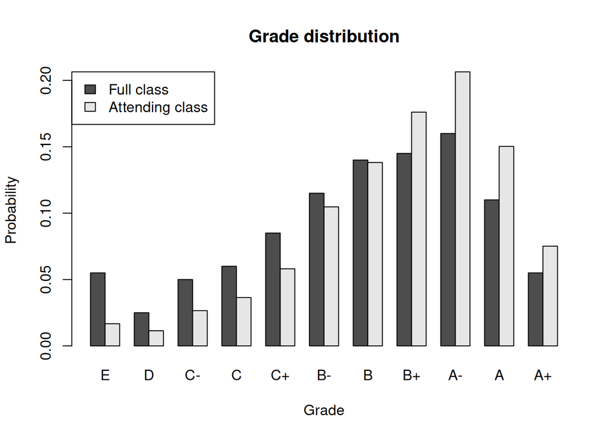

   ```r
   barplot(t(as.matrix(gdist[,c("pg","pg.a")])), names=gdist$gnames, beside=TRUE,
           xlab="Grade", ylab="Probability",
           legend=TRUE,
           legend.text=c("Full class","Attending class"),
           args.legend=list(x="topleft"))
   title("Grade distribution")
   ```

#### Decision Trees

I’m trying to decide whether to play a game or not. Here are the rules.

- If I join the game I pay a stake S=$100
- then a six sided die is rolled once
- I get $300 if the die shows a 6,
- I get $20 if it’s an odd number (1, 3 or 5),
- I get $0 otherwise (i.e. a 2 or a 4)

My utility is just the amount of cash I have at the end.

Should I play this game?

##### Questions

1. Draw a decision tree representing this game.
2. Estimate the value of the chance node.
3. Decide whether I should play.

##### Answers

1. Decision tree

   ```r
   ystr <- c(
     "name:  Play Game?",
     "type:  decision",
     "Play:",
     "  type: chance",
     "  Roll 6:",
     "    type: terminal",
     "    payoff: -100+300",
     "    p:      1/6",
     "  Roll Odd:",
     "    type: terminal",
     "    payoff: -100+20",
     "    p:      3/6",
     "  Roll 2 or 4:",
     "    type: terminal",
     "    payoff: -100",
     "    p:      2/6",
     "Do not Play:",
     "  type: terminal",
     "  payoff: 0")
   ytree.y <- yaml.load(ystr)
   ytree <- as.Node(ytree.y)
   #ytree$Do(payoff, traversal = "post-order", filterFun = isNotLeaf)
   #ytree$Do(decision, filterFun = function(x) x$type == 'decision')
   payoff <- function(node) {
     if (node$type == 'chance') node$payoff <- sum(sapply(node$children, function(child) child$payoff * child$p))
     else if (node$type == 'decision') node$payoff <- max(sapply(node$children, function(child) child$payoff))
   }
   decision <- function(x) {
     po <- sapply(x$children, function(child) child$payoff)
     x$decision <- names(po[po == x$payoff])
   }
   GetNodeShape <- function(node) switch(node$type, decision = "box", chance = "circle", terminal = "none")
   GetNodeLabel.terminal <- function(node) switch(node$type,
                                     terminal = node$payoff)
   GetNodeLabel <- function(node) switch(node$type,
                                     terminal = paste0(format(node$payoff, scientific = FALSE, big.mark = ",")),
                                     paste0(format(node$payoff, scientific = FALSE, big.mark = ",")))
   GetEdgeLabel <- function(node) {
     if (!node$isRoot && node$parent$type == 'chance') {
       label = paste0(node$name, " (", node$p, ")")
     } else {
       label = node$name
     }
     return (label)
   }
   SetEdgeStyle(ytree, fontname = 'helvetica', label = GetEdgeLabel)
   SetNodeStyle(ytree, fontname = 'helvetica', label = GetNodeLabel.terminal, shape = GetNodeShape)
   SetGraphStyle(ytree, rankdir = "LR")
   ```

   ```r
   plot(ytree, width=640, height=220)
   ```

[interactive chart not shown]

2. Evaluate the chance node
   $$E[\text{Play}] = (1/6)(200) + (3/6)(-80) + (2/6)(-100) = -40$$

   ```r
   ystr <- c(
     "name:  Play Game?",
     "type:  decision",
     "Play:",
     "  type: chance",
     "  Roll 6:",
     "    type: terminal",
     "    payoff: 200",
     "    p:      0.16667",
     "  Roll Odd:",
     "    type: terminal",
     "    payoff: -80",
     "    p:      0.500",
     "  Roll 2 or 4:",
     "    type: terminal",
     "    payoff: -100",
     "    p:      0.33333",
     "Do not Play:",
     "  type: terminal",
     "  payoff: 0")
   ytree.y <- yaml.load(ystr)
   ytree <- as.Node(ytree.y)
   ytree$Do(payoff, traversal = "post-order", filterFun = isNotLeaf)
   ytree$Do(decision, filterFun = function(x) x$type == 'decision')
   GetNodeLabel.terminal <- function(node) switch(node$type,
                                     terminal = node$payoff)
   GetNodeLabel <- function(node) switch(node$type,
                                     terminal = paste0(format(node$payoff, scientific = FALSE, big.mark = ",")),
                                     paste0(round(node$payoff)))
   GetEdgeLabel <- function(node) {
     if (!node$isRoot && node$parent$type == 'chance') {
       label = paste0(node$name, " (", node$p, ")")
     } else {
       label = node$name
     }
     return (label)
   }
   SetEdgeStyle(ytree, fontname = 'helvetica', label = GetEdgeLabel)
   SetNodeStyle(ytree, fontname = 'helvetica', label = GetNodeLabel, shape = GetNodeShape)
   SetGraphStyle(ytree, rankdir = "LR")
   ```

   ```r
   plot(ytree, width=640, height=220)
   ```

[interactive chart not shown]

3. Final decision

   The Expected Utility of playing is -$40, which is less than the Expected Utility of not playing $0 - so we shouldn’t play.

#### Decision Trees

I’m suing my former employer for wrongful dismissal.

- If I settle out of court I’ll get $40,000.
- If I go to court there is a 70% chance that I’ll lose the case I get nothing.
- If I win the case there’s a 50% chance I’ll get a large payout of $300,000, and a 50% chance I’ll get a small payout of $50,000.

What should I do?

##### Questions

1. Draw a decision tree.
2. Estimate the value of the chance node.
3. Decide whether I should to to court based on the expected maximum return.
4. Assume my utility function is actually $U(r)=\sqrt{r}$, and redo the problem. Is my decision any different? Why?

(Question is from Winston 2004, Ch 13, Problem A4.)

##### Answers

1. Decision tree

   ```r
   ystr <- c(
     "name:  Go to court?",
     "type:  decision",
     "Settle:",
     "  type: terminal",
     "  payoff: 40000",
     "Go to Court:",
     "  type: chance",
     "  Lose:",
     "    type:   terminal",
     "    payoff: 0",
     "    p:      0.70",
     "  Win:",
     "    type:   chance",
     "    p:      0.30",
     "    Large:",
     "       type:   terminal",
     "       payoff: 300000",
     "       p:      0.5",
     "    Small:",
     "       type:   terminal",
     "       payoff: 50000",
     "       p:      0.5")
   ytree.y <- yaml.load(ystr)
   ytree <- as.Node(ytree.y)
   #ytree$Do(payoff, traversal = "post-order", filterFun = isNotLeaf)
   #ytree$Do(decision, filterFun = function(x) x$type == 'decision')
   payoff <- function(node) {
     if (node$type == 'chance') node$payoff <- sum(sapply(node$children, function(child) child$payoff * child$p))
     else if (node$type == 'decision') node$payoff <- max(sapply(node$children, function(child) child$payoff))
   }
   decision <- function(x) {
     po <- sapply(x$children, function(child) child$payoff)
     x$decision <- names(po[po == x$payoff])
   }
   GetNodeShape <- function(node) switch(node$type, decision = "box", chance = "circle", terminal = "none")
   GetNodeLabel.terminal <- function(node) switch(node$type,
                                     terminal = node$payoff)
   GetNodeLabel <- function(node) switch(node$type,
                                     terminal = paste0(format(node$payoff, scientific = FALSE, big.mark = ",")),
                                     paste0(format(node$payoff, scientific = FALSE, big.mark = ",")))
   GetEdgeLabel <- function(node) {
     if (!node$isRoot && node$parent$type == 'chance') {
       label = paste0(node$name, " (", node$p, ")")
     } else {
       label = node$name
     }
     return (label)
   }
   SetEdgeStyle(ytree, fontname = 'helvetica', label = GetEdgeLabel)
   SetNodeStyle(ytree, fontname = 'helvetica', label = GetNodeLabel.terminal, shape = GetNodeShape)
   SetGraphStyle(ytree, rankdir = "LR")
   ```

   ```r
   plot(ytree, width=640, height=220)
   ```

[interactive chart not shown]

2. Evaluate chance nodes

   $$\begin{eqnarray*}
   E[\text{Win}|\text{Go to Court}] &=& (0.5)(300000) +
   (0.5)(50000) = 175000\\
   E[\text{Go to Court}] &=& (0.3)(175000) + (0.7)(0) = 52500
   \end{eqnarray*}$$

   ```r
   ytree$Do(payoff, traversal = "post-order", filterFun = isNotLeaf)
   ytree$Do(decision, filterFun = function(x) x$type == 'decision')
   GetNodeLabel.terminal <- function(node) switch(node$type,
                                     terminal = node$payoff)
   GetNodeLabel <- function(node) switch(node$type,
                                     terminal = paste0(format(node$payoff, scientific = FALSE, big.mark = ",")),
                                     paste0(round(node$payoff)))
   GetEdgeLabel <- function(node) {
     if (!node$isRoot && node$parent$type == 'chance') {
       label = paste0(node$name, " (", node$p, ")")
     } else {
       label = node$name
     }
     return (label)
   }
   SetEdgeStyle(ytree, fontname = 'helvetica', label = GetEdgeLabel)
   SetNodeStyle(ytree, fontname = 'helvetica', label = GetNodeLabel, shape = GetNodeShape)
   SetGraphStyle(ytree, rankdir = "LR")
   ```

   ```r
   plot(ytree, width=640, height=220)
   ```

[interactive chart not shown]

3. Final decision

   The Expected Return of going to court is higher than settling ($52,500 vs. $40,000), so I should go to court
4. Assume my utility function is actually $U(r)=\sqrt{r}$, and redo the problem. Is my decision any different? Why?

   ```r
   ystr <- c(
     "name:  Go to court?",
     "type:  decision",
     "Settle:",
     "  type: terminal",
     "  payoff: 200.00",
     "Go to Court:",
     "  type: chance",
     "  Lose:",
     "    type:   terminal",
     "    payoff: 0",
     "    p:      0.70",
     "  Win:",
     "    type:   chance",
     "    p:      0.30",
     "    Large:",
     "       type:   terminal",
     "       payoff: 548.72",
     "       p:      0.5",
     "    Small:",
     "       type:   terminal",
     "       payoff: 223.61",
     "       p:      0.5")
   ytree.y <- yaml.load(ystr)
   ytree <- as.Node(ytree.y)
   #ytree$Do(payoff, traversal = "post-order", filterFun = isNotLeaf)
   #ytree$Do(decision, filterFun = function(x) x$type == 'decision')
   payoff <- function(node) {
     if (node$type == 'chance') node$payoff <- sum(sapply(node$children, function(child) child$payoff * child$p))
     else if (node$type == 'decision') node$payoff <- max(sapply(node$children, function(child) child$payoff))
   }
   decision <- function(x) {
     po <- sapply(x$children, function(child) child$payoff)
     x$decision <- names(po[po == x$payoff])
   }
   GetNodeShape <- function(node) switch(node$type, decision = "box", chance = "circle", terminal = "none")
   GetNodeLabel.terminal <- function(node) switch(node$type,
                                     terminal = node$payoff)
   GetNodeLabel <- function(node) switch(node$type,
                                     terminal = paste0(format(node$payoff, scientific = FALSE, big.mark = ",")),
                                     paste0(format(node$payoff, scientific = FALSE, big.mark = ",")))
   GetEdgeLabel <- function(node) {
     if (!node$isRoot && node$parent$type == 'chance') {
       label = paste0(node$name, " (", node$p, ")")
     } else {
       label = node$name
     }
     return (label)
   }
   SetEdgeStyle(ytree, fontname = 'helvetica', label = GetEdgeLabel)
   SetNodeStyle(ytree, fontname = 'helvetica', label = GetNodeLabel.terminal, shape = GetNodeShape)
   SetGraphStyle(ytree, rankdir = "LR")
   ```

   ```r
   plot(ytree, width=640, height=220)
   ```

[interactive chart not shown]

   Evaluating the chance nodes:

   ```r
   ytree$Do(payoff, traversal = "post-order", filterFun = isNotLeaf)
   ytree$Do(decision, filterFun = function(x) x$type == 'decision')
   GetNodeLabel.terminal <- function(node) switch(node$type,
                                     terminal = node$payoff)
   GetNodeLabel <- function(node) switch(node$type,
                                     terminal = paste0(format(node$payoff, scientific = FALSE, big.mark = ",")),
                                     paste0(round(node$payoff)))
   GetEdgeLabel <- function(node) {
     if (!node$isRoot && node$parent$type == 'chance') {
       label = paste0(node$name, " (", node$p, ")")
     } else {
       label = node$name
     }
     return (label)
   }
   SetEdgeStyle(ytree, fontname = 'helvetica', label = GetEdgeLabel)
   SetNodeStyle(ytree, fontname = 'helvetica', label = GetNodeLabel, shape = GetNodeShape)
   SetGraphStyle(ytree, rankdir = "LR")
   ```

   ```r
   plot(ytree, width=640, height=220)
   ```

[interactive chart not shown]

   The expected utility of settling out of court is higher (200) than going to court (116).

   This is because my **concave** (downward curving) utility function $U(r)=\sqrt{r}$ makes me **risk averse**, and I incline more towards the sure payoff and away from larger but risky possible gains.